# WGCNA

## Data quality assessment by sample clustering and visualization

### Heatmap of the sample-to-sample distances

```r
sampleDists <- dist(t(assay(vst2)))
```

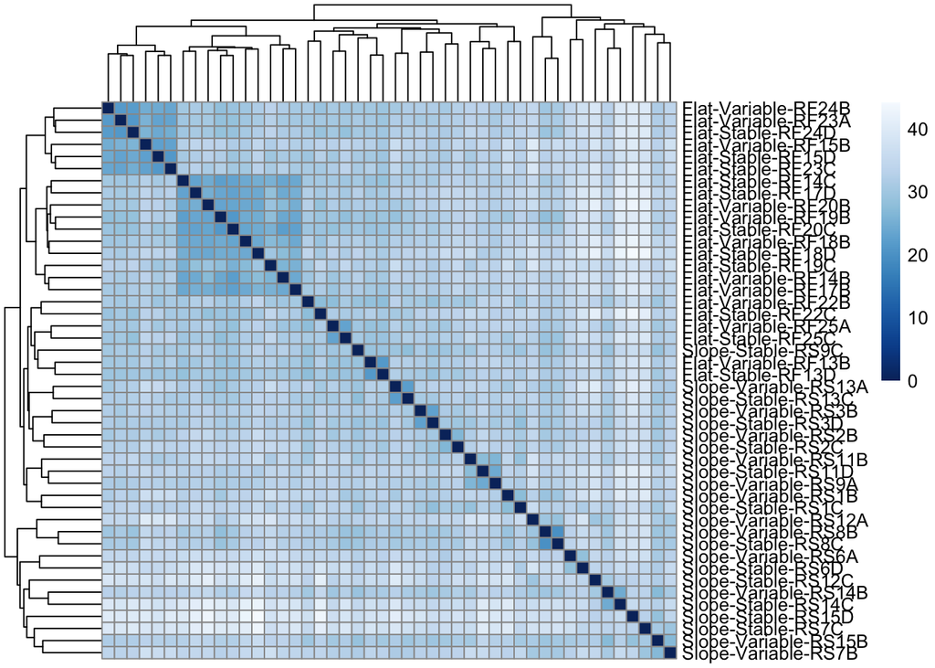

```r
library("RColorBrewer")
sampleDistMatrix <- as.matrix(sampleDists)
rownames(sampleDistMatrix) <- paste(vst2$Origin, vst2$Treatment, vst2$Coral_ID, sep="-")
colnames(sampleDistMatrix) <- NULL
colors <- colorRampPalette( rev(brewer.pal(9, "Blues")) )(255)
pheatmap(sampleDistMatrix,
         clustering_distance_rows=sampleDists,
         clustering_distance_cols=sampleDists,
         col=colors)
```

###Principal component plot of the samples

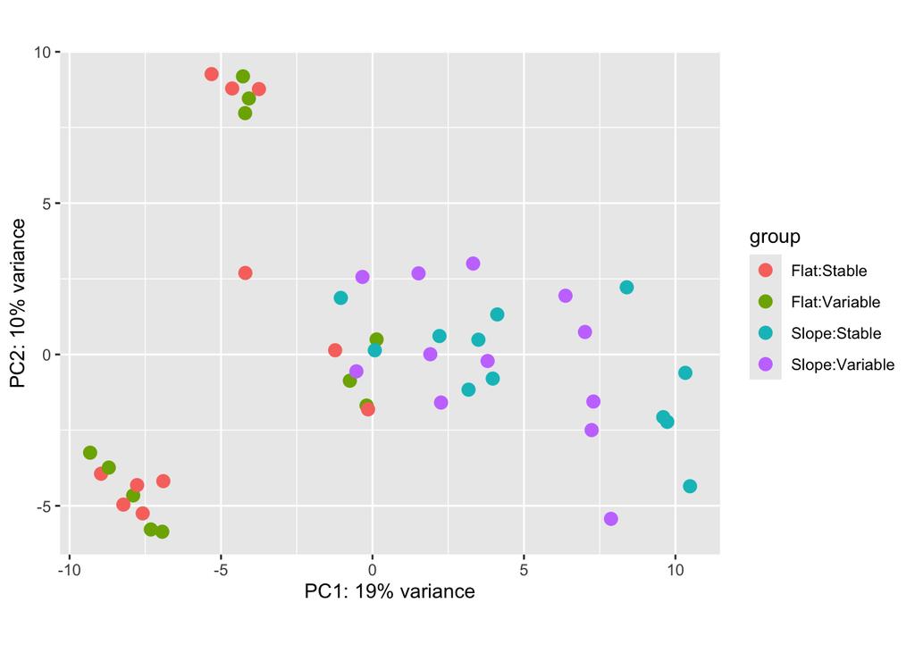

```r
withoutoutliers <- plotPCA(vst2, intgroup=c("Origin", "Treatment"))
withoutoutliers
```

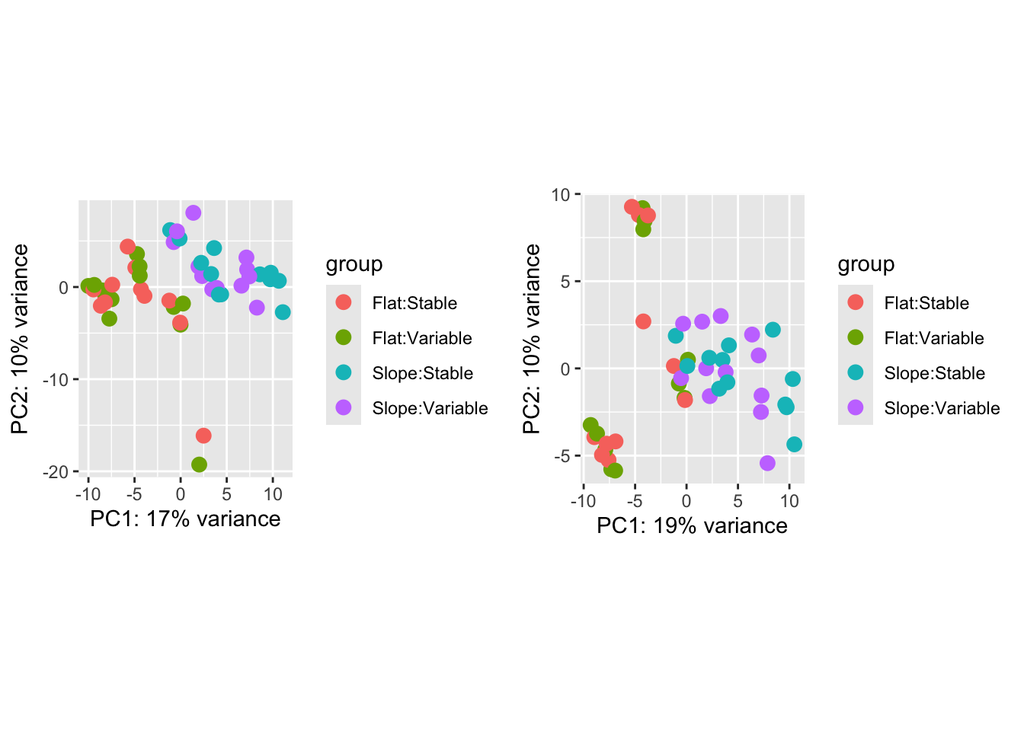

```r
compare_figs <- cowplot::plot_grid(withoutliers, withoutoutliers,ncol=2, align="h")
compare_figs
```

```r
# transform the data
vst2 <- vst(dds2) # transform it vst
vst2 <- assay(vst2) # call only the transformed coutns in the dds object
vst2 <- t(vst2) # transpose columns to rows and vice versa
```

## Check for genes and samples with too many missing values with goodSamplesGenes. There shouldn’t be any because we performed pre-filtering

```r
dim(vst2) #  9012 genes; 46  samples
```

```
## [1]   46 9012
```

```r
gsg <- goodSamplesGenes(vst2, verbose = 3);  # We first check for genes and samples with too many missing values
```

```
##  Flagging genes and samples with too many missing values...
##   ..step 1
```

```r
gsg$allOK # If the statement returns TRUE, all genes have passed the cuts.
```

```
## [1] TRUE
```

## Conduct WGCNA

```r
library(WGCNA)
# The following setting is important, do not omit.
options(stringsAsFactors = FALSE)
```

```r
##Soft threshold
dim(vst2) #  46 9012
```

```
## [1]   46 9012
```

```r
# Choose a set of soft-thresholding powers
powers = c(c(1:10), seq(from = 12, to=20, by=2))
# Call the network topology analysis function

#the below takes a long time to run, so is commented out and the pre-run results are loaded in below
## sft = pickSoftThreshold(vst2, powerVector = powers, verbose = 5) #...wait for this to finish
## save(sft, file = "../../output/WGCNA/sft.RData")
load("../../output/WGCNA/sft.RData")

# pickSoftThreshold
#  performs the analysis of network topology and aids the
# user in choosing a proper soft-thresholding power.
# The user chooses a set of candidate powers (the function provides suitable default values)
# function returns a set of network indices that should be inspected

sizeGrWindow(9, 5) # set window size
# png to output
png("../../output/WGCNA/sft.png", 1000, 1000, pointsize=20)
par(mfrow = c(1,2));
cex1 = 0.9;
# Scale-free topology fit index as a function of the soft-thresholding power
plot(sft$fitIndices[,1], -sign(sft$fitIndices[,3])*sft$fitIndices[,2],
     xlab="Soft Threshold (power)",ylab="Scale Free Topology Model Fit,signed R^2",type="n",
     main = paste("Scale independence"));

text(sft$fitIndices[,1], -sign(sft$fitIndices[,3])*sft$fitIndices[,2],
     labels=powers,cex=cex1,col="red");

# this line corresponds to using an R^2 cut-off of h
abline(h=0.90,col="red")

# Mean connectivity as a function of the soft-thresholding power
plot(sft$fitIndices[,1], sft$fitIndices[,5],
     xlab="Soft Threshold (power)",ylab="Mean Connectivity", type="n",
     main = paste("Mean connectivity"))
text(sft$fitIndices[,1], sft$fitIndices[,5], labels=powers, cex=cex1,col="red")
dev.off() # output
```

```r
#I used a scale-free topology fit index **R^2 of 0.9**. This lowest recommended R^2 by Langfelder and Horvath is 0.8. I chose 0.9 because we want to use the smallest soft thresholding power that maximizes with model fit. It appears that our **soft thresholding power is 5** because it is the lowest power above the R^2=0.9 threshold that maximizes with model fit.
```

## Look for outliers by examining tree of samples

```r
sampleTree = hclust(dist(vst2), method = "average") # Next we cluster the samples (in contrast to clustering genes that will come later)  to see if there are any obvious outliers.There don't look to be any outliers, so we will move on with business as usual.
sizeGrWindow(12,9)
par(cex = 0.6);
par(mar = c(0,4,2,0))
plot(sampleTree)
```

[output not shown]

## Start the step-wise module construction:

#### Step 1: Create adjacency matrix

```r
softPower = 5 # set the soft threshold based on the plots above

# signed
#to get this to work with a ton of genes >30K, I had to increase my memory limit using: memory.limit(size = 35000)
adjacency_sign = adjacency(vst2, power = softPower, type="signed")  #Calculate adjacency
```

### Step 2: Turn adjacency into topological overlap: Calculation of the topological overlap matrix, (TOM) and the corresponding dissimilarity, from a given adjacency matrix.

```r
#the below takes a long time to run, so is commented out and the pre-run results are loaded in below
## TOM_sign = TOMsimilarity(adjacency_sign, TOMType="signed") #Translate adjacency into topological overlap matrix
## save(TOM_sign, file = "../../output/WGCNA/TOM_sign.Rdata")
load("../../output/WGCNA/TOM_sign.Rdata")

dissTOM_sign   = 1-TOM_sign
```

### Step 3: Call the hierarchical clustering function - plot the tree

```r
# Call the hierarchical clustering function
#to get this to work, I had to increase my memory limit using: memory.limit(size = 45000)
geneTree_sign   = hclust(as.dist(dissTOM_sign), method = "average");

# Plot the resulting clustering tree (dendrogram) Each leaf corresponds to a gene, branches grouping together densely are interconnected, highly co-expressed genes.
sizeGrWindow(12,9)

plot(geneTree_sign, xlab="", sub="", main = "Gene clustering on TOM-based dissimilarity - SIGNED",
     labels = FALSE, hang = 0.04);
```

[output not shown]

### Step 4: Set module size and ‘cutreeDynamic’ to create clusters

```r
#Module identification is essentially cutting the branches off the tree in the dendrogram above. We like large modules, so we set the **minimum module size** relatively high, so we will set the minimum size at 30.
minModuleSize = 30; # set this for the subseqent call...

dynamicMods_sign = cutreeDynamic(dendro = geneTree_sign, distM = dissTOM_sign,
                            deepSplit = 1, pamRespectsDendro = FALSE,
                            minClusterSize = minModuleSize);
```

```
##  ..cutHeight not given, setting it to 0.959  ===>  99% of the (truncated) height range in dendro.
##  ..done.
```

```r
table(dynamicMods_sign) # number of genes per module. Module 0 is reserved for unassigned genes. The are other modules will be listed largest to smallest.
```

```
## dynamicMods_sign
##    1    2    3    4    5    6    7    8    9   10   11   12   13   14   15   16
## 2558 1809  942  917  500  425  396  220  219  218  180  170  154  105   71   65
##   17
##   63
```

### Step 5: convert numeric network to colors and plot the dendrogram

```r
# Convert numeric lables into colors
dynamicColors_sign = labels2colors(dynamicMods_sign) # add colors to module labels (previously numbers)
table(dynamicColors_sign) # lets look at this table...
```

```
## dynamicColors_sign
##        black         blue        brown         cyan        green  greenyellow
##          396         1809          942          105          500          180
##       grey60    lightcyan      magenta midnightblue         pink       purple
##           63           65          219           71          220          218
##          red       salmon          tan    turquoise       yellow
##          425          154          170         2558          917
```

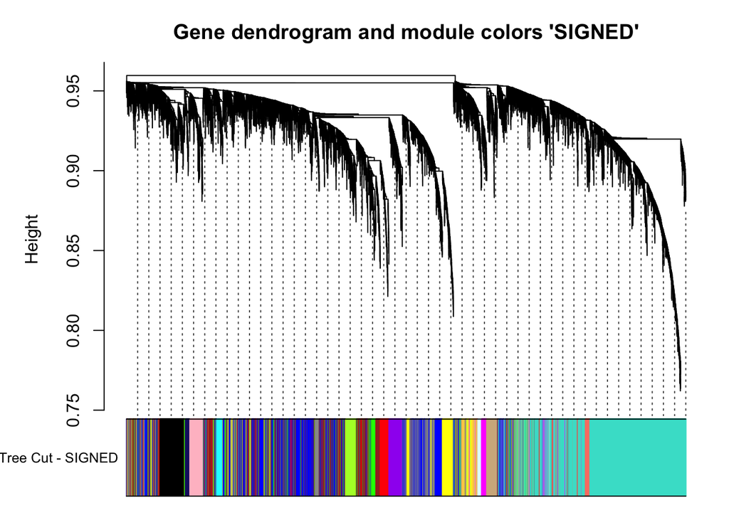

```r
# Plot the dendrogram and colors underneath

plotDendroAndColors(geneTree_sign, dynamicColors_sign, "Dynamic Tree Cut - SIGNED",
                    dendroLabels = FALSE, hang = 0.03,
                    addGuide = TRUE, guideHang = 0.05,
                    main = "Gene dendrogram and module colors 'SIGNED'")
```

```r
sizeGrWindow(8,6)
png("../../output/WGCNA/GeneDendrogram.png", 1000, 1000, pointsize=20)
plotDendroAndColors(geneTree_sign, dynamicColors_sign, "Dynamic Tree Cut - SIGNED",
                    dendroLabels = FALSE, hang = 0.03,
                    addGuide = TRUE, guideHang = 0.05,
                    main = "Gene dendrogram and module colors 'SIGNED'")
dev.off()
```

### Step 6: Calculate Eigengenes - view thier connectivity based on ‘MEDiss = 1-cor(MEs)’

```r
# Calculate eigengenes
MEList = moduleEigengenes(vst2, colors = dynamicColors_sign, softPower = 5)

MEs = MEList$eigengenes
MEs
```

```
##            MEblack        MEblue      MEbrown        MEcyan     MEgreen
## RF13B  0.035738890 -0.0005614067  0.086214000  0.0230457125  0.06457070
## RF13D  0.016715232  0.0355808790  0.077795819  0.0108599933  0.04977675
## RF14B -0.146566530 -0.0989830172  0.243945678  0.0089738153  0.09690707
## RF14C -0.144417844  0.0293510325  0.231391380  0.0555552483  0.12492062
## RF15B  0.361363331  0.0125541542  0.195194429  0.0669848895  0.09848360
## RF15D  0.340691436 -0.0628815348  0.130600265  0.0613695551  0.15041068
## RF17B -0.166389167 -0.0083085168  0.198989474 -0.0330477836  0.06580995
## RF17D -0.174336507  0.0274499964  0.242761454  0.0109581641  0.20156729
## RF18B -0.163062969  0.0730460426  0.213165173  0.0428568437  0.15059016
## RF18D -0.198796035  0.1501095732  0.221598881  0.0156327910  0.26172808
## RF19B -0.052085383  0.1809702199  0.156245872  0.0534562058  0.11871425
## RF19C -0.133192276 -0.1908284494  0.207082710  0.0058409291  0.09057738
## RF20B -0.203191630  0.1418285398  0.167736368  0.0175489549  0.09355805
## RF20C -0.079445376  0.0589582967  0.220340540  0.0517627628  0.08359879
## RF22B  0.013623481 -0.1171079552  0.003985773  0.0146616850 -0.06040064
## RF22C -0.011991191  0.1497873255  0.042606148  0.0054811614 -0.06439484
## RF23A  0.312454266  0.1092940451  0.061065835  0.0347675690  0.09520240
## RF23C  0.295349869  0.0345798457  0.114909745  0.0202737297  0.03245128
## RF24B  0.356715054  0.1929708845  0.106044589  0.0913070182  0.03457393
## RF24D  0.306302794  0.1516425029  0.076269408  0.0729544308  0.08671047
## RF25A  0.080575924 -0.0834460336 -0.007865851 -0.0080197431 -0.04258953
## RF25C  0.093458065  0.1069453692 -0.019058548  0.0240384357  0.09631201
## RS11B -0.004644330 -0.1099408605 -0.092245924  0.0376314369  0.10628308
## RS11D -0.026519519  0.0766325673 -0.153945434  0.0009392144  0.34571416
## RS12A -0.018592944  0.0934519345 -0.215804220  0.0079270236 -0.25126870
## RS12C  0.025448390 -0.2497580080 -0.180395235  0.0528064649 -0.06947225
## RS13A -0.013832874  0.2242246956 -0.087780763  0.0043265989 -0.17859214
## RS13C -0.016960538  0.0901775914 -0.092445893  0.0264009339 -0.20267882
## RS14B -0.025815615 -0.1101678607 -0.138277199  0.0152473895 -0.14673511
## RS14C -0.093490223 -0.3533046553 -0.224348383 -0.0853239910 -0.29804769
## RS15B -0.043303446 -0.0724784483 -0.135120081  0.0254364294 -0.25047579
## RS15D -0.063247364 -0.4464606863 -0.250028576  0.0434992663 -0.21085363
## RS1B  -0.071734949  0.1666814228 -0.146538808  0.0318043922  0.01154907
## RS1C  -0.081189863 -0.0208045578 -0.082597955  0.0382703168  0.03230402
## RS2B   0.081141470  0.0226962013 -0.046649316 -0.0191289688 -0.10542840
## RS2C   0.001196774  0.0341686249 -0.061856762  0.0202354959 -0.13064096
## RS3B  -0.007344414  0.0096703526 -0.121890691  0.0118973832 -0.01743041
## RS3D  -0.005781953  0.0046080335 -0.079855011  0.0442362556  0.03886139
## RS6A  -0.070105162 -0.0231943131 -0.147206872 -0.9641101677 -0.14047140
```

[output cut: 133 more lines]

```
## RS15D  0.307123864 -0.172427392
## RS1B  -0.101737577  0.104667302
## RS1C   0.143128087 -0.183411878
## RS2B   0.100982719 -0.083769236
## RS2C   0.024999718 -0.048380219
## RS3B   0.024856931 -0.037476547
## RS3D   0.065598226 -0.130456228
## RS6A   0.076021058 -0.120889165
## RS6D   0.237997729 -0.426863340
## RS7B   0.010898755  0.148428399
## RS7C   0.300330368 -0.232336901
## RS8B  -0.059359541  0.115675577
## RS8C  -0.069784904  0.204699604
## RS9A  -0.029634459 -0.091637783
## RS9C   0.046386423  0.048294943
```

```r
library(dplyr)
MEs <- MEs %>%
    select_if(~ !any(is.na(.)))

# Calculate dissimilarity of module eigengenes
MEDiss = 1-cor(MEs, use = "pairwise.complete.obs");

# Cluster module eigengenes
METree = hclust(as.dist(MEDiss), method = "average");
# Plot the result
sizeGrWindow(7, 6)
png("../../output/WGCNA/ClusterEigengenes.png", 1000, 1000, pointsize=20)
plot(METree, main = "Clustering of module eigengenes - SIGNED (dissimilarity calc = MEDiss = 1-cor(MEs))",
     xlab = "", sub = "")
MEDissThres = 0.15
abline(h=MEDissThres, col = "red")
dev.off()
```

### Step 7: Specify the cut line for the dendrogram (module) - Calc MODULE EIGENGENES (mergeMEs)

#### We had 17 modules before merging, and 15 modules after merging

```r
MEDissThres = 0.15 # **Merge modules with >85% eigengene similarity.** Most studies use somewhere between 80-90% similarity. I will use 85% similarity as my merging threshold.
# Plot the cut line into the dendrogram
#abline(h=MEDissThres, col = "red")
# Call an automatic merging function
# merge = mergeCloseModules(dds.d0_vst, dynamicColors, cutHeight = MEDissThres, verbose = 3)
merge = mergeCloseModules(vst2, dynamicColors_sign, cutHeight = MEDissThres, verbose = 3)
```

```
##  mergeCloseModules: Merging modules whose distance is less than 0.15
##    multiSetMEs: Calculating module MEs.
##      Working on set 1 ...
##      moduleEigengenes: Calculating 17 module eigengenes in given set.
##    multiSetMEs: Calculating module MEs.
##      Working on set 1 ...
##      moduleEigengenes: Calculating 15 module eigengenes in given set.
##    Calculating new MEs...
##    multiSetMEs: Calculating module MEs.
##      Working on set 1 ...
##      moduleEigengenes: Calculating 15 module eigengenes in given set.
```

```r
# The merged module colors
mergedColors = merge$colors;
# Eigengenes of the new merged modules:
mergedMEs = merge$newMEs;
library(dplyr)
mergedMEs <- mergedMEs %>%
    select_if(~ !any(is.na(.)))
# Cluster module eigengenes
MEDiss2 = 1-cor(mergedMEs,use = 'pairwise.complete.obs');
MEDiss2
```

```
##                   MEcyan   MEblack     MEsalmon    MEpink     MEred   MEgreen
## MEcyan         0.0000000 0.8363810 9.456342e-01 1.0357865 0.9335928 0.8183041
## MEblack        0.8363810 0.0000000 5.863287e-01 0.6853443 0.6615370 0.9676272
## MEsalmon       0.9456342 0.5863287 3.330669e-16 0.3469933 0.5950190 0.9701274
## MEpink         1.0357865 0.6853443 3.469933e-01 0.0000000 0.1847992 0.7966365
## MEred          0.9335928 0.6615370 5.950190e-01 0.1847992 0.0000000 0.5869122
## MEgreen        0.8183041 0.9676272 9.701274e-01 0.7966365 0.5869122 0.0000000
## MEmidnightblue 0.8698516 0.8018912 5.817853e-01 0.6693067 0.7309443 0.2592991
## MEblue         0.9280028 0.7794428 1.490247e+00 1.0050357 0.6357651 0.5714618
## MEbrown        0.8001074 0.9517543 7.364483e-01 0.5916456 0.3078619 0.4095681
## MEpurple       0.9256202 1.5772808 1.197132e+00 1.0905539 0.7866850 0.5726397
## MEturquoise    1.1349435 0.9426693 5.237657e-01 0.9541162 1.4074916 1.5287035
## MEtan          0.9540523 1.6478878 1.185038e+00 1.4159836 1.2577153 1.0651031
## MEmagenta      1.0943541 1.4972583 1.596656e+00 1.7187830 1.8343444 1.5388426
## MElightcyan    0.9911347 1.2290197 1.671253e+00 1.7962628 1.6277834 1.4917147
## MEyellow       0.8784473 1.2609555 1.706417e+00 1.5933035 1.2003612 1.0077827
##                MEmidnightblue    MEblue   MEbrown  MEpurple MEturquoise
## MEcyan              0.8698516 0.9280028 0.8001074 0.9256202   1.1349435
## MEblack             0.8018912 0.7794428 0.9517543 1.5772808   0.9426693
## MEsalmon            0.5817853 1.4902471 0.7364483 1.1971317   0.5237657
## MEpink              0.6693067 1.0050357 0.5916456 1.0905539   0.9541162
## MEred               0.7309443 0.6357651 0.3078619 0.7866850   1.4074916
## MEgreen             0.2592991 0.5714618 0.4095681 0.5726397   1.5287035
## MEmidnightblue      0.0000000 1.0911109 0.7673563 1.0220637   0.9399263
## MEblue              1.0911109 0.0000000 0.6094019 0.7720365   1.8569108
## MEbrown             0.7673563 0.6094019 0.0000000 0.2973886   1.6531319
## MEpurple            1.0220637 0.7720365 0.2973886 0.0000000   1.6328755
## MEturquoise         0.9399263 1.8569108 1.6531319 1.6328755   0.0000000
## MEtan               1.1727525 1.3358764 0.8763249 0.3437970   1.0458386
## MEmagenta           1.4884948 1.2900461 1.7130179 1.1285645   0.6777335
## MElightcyan         1.6092707 0.9317914 1.4922356 1.0135890   1.0509252
## MEyellow            1.4254228 0.5307596 0.9419223 0.5606714   1.6026729
##                    MEtan MEmagenta  MElightcyan  MEyellow
## MEcyan         0.9540523 1.0943541 9.911347e-01 0.8784473
## MEblack        1.6478878 1.4972583 1.229020e+00 1.2609555
## MEsalmon       1.1850376 1.5966556 1.671253e+00 1.7064168
## MEpink         1.4159836 1.7187830 1.796263e+00 1.5933035
## MEred          1.2577153 1.8343444 1.627783e+00 1.2003612
## MEgreen        1.0651031 1.5388426 1.491715e+00 1.0077827
## MEmidnightblue 1.1727525 1.4884948 1.609271e+00 1.4254228
## MEblue         1.3358764 1.2900461 9.317914e-01 0.5307596
## MEbrown        0.8763249 1.7130179 1.492236e+00 0.9419223
## MEpurple       0.3437970 1.1285645 1.013589e+00 0.5606714
## MEturquoise    1.0458386 0.6777335 1.050925e+00 1.6026729
## MEtan          0.0000000 0.6018516 6.027920e-01 0.5881998
## MEmagenta      0.6018516 0.0000000 2.388853e-01 0.6635948
## MElightcyan    0.6027920 0.2388853 1.110223e-16 0.2320545
## MEyellow       0.5881998 0.6635948 2.320545e-01 0.0000000
```

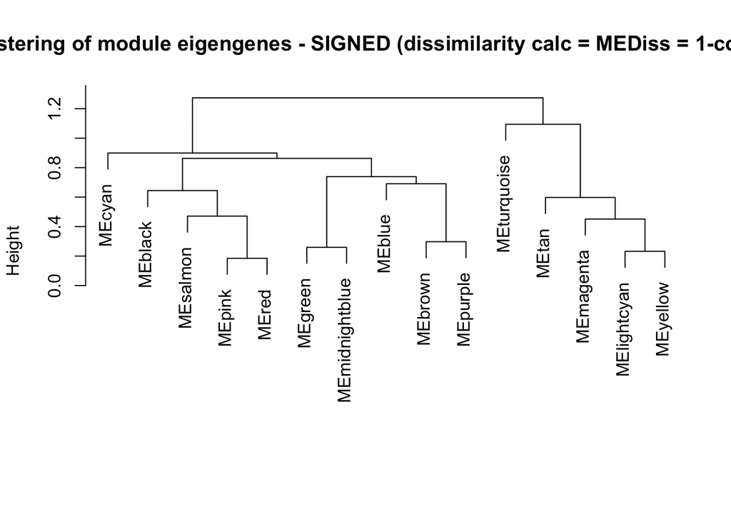

```r
METree2 = hclust(as.dist(MEDiss2), method = "average");
# Plot the result
plot(METree2, main = "Clustering of module eigengenes - SIGNED (dissimilarity calc = MEDiss = 1-cor(MEs))",
     xlab = "", sub = "")
```

```r
sizeGrWindow(7, 6)
png("../../output/WGCNA/ClusterEigengenes_merged.png", 1000, 1000, pointsize=20)
plot(METree2, main = "Clustering of module eigengenes - SIGNED (dissimilarity calc = MEDiss = 1-cor(MEs))",
     xlab = "", sub = "")
dev.off()
```